# MATH 140: Using ggplot

Hitchman

In some R activities you will be asked to produce graphics using *ggplot2*, a nice graphics package in R. In this tutorial we focus on three types of graphics: histograms, scatter plots, and box plots.

**I encourage you to replicate all the graphs in this tutorial in your own RStudio session.**

In order to produce graphics with *ggplot2*, you need to load it into your RStudio session. The *ggplot2* package is part of the *tidyverse* package, so begin your session by loading the tidyverse. Recall, do do this, run the line

```
library(tidyverse)
```

With the tidyverse loaded, you are ready to use the ggplot functions for generating graphs.

All the plots in this tutorial use the Old Faithful data set that comes built-in to the RStudio program.

With the code below, you can load the data into your session with the working name `df` (short for data frame). The code below also displays the first eight rows of the data frame, to help familiarize yourself with the data set. The data set records information about $n = 272$ eruptions of the Old Faithful geyser. The `eruptions` variable indicates how long the eruption lasted (in minutes), and the `waiting` variable indicates how long the wait was until the next eruption (in minutes).

```r
df <- faithful
head(df,8)
```

```
##   eruptions waiting
## 1     3.600      79
## 2     1.800      54
## 3     3.333      74
## 4     2.283      62
## 5     4.533      85
## 6     2.883      55
## 7     4.700      88
## 8     3.600      85
```

Code for plots with the ggplot package will have this general look:

```
ggplot(data = ..., aes(x = ... , y= ... , etc.)) +
  [plot type, with options in parentheses] +
  [other layer, such as plot title] +
  [other layer, such as a plot theme, or axis label]+
  [other layer]+...
```

Two remarks before showing many examples.

1. We need a `+` sign at the end of each line if we plan to add another layer. The last line should not end with a `+` sign.
2. We specify variables involved in a plot within the `aes()` command, `aes` being short for *aesthetic*. The dots and lines in plots have certain locations, colors, shapes, and sizes. In ggplot, these features are called *aesthetics*.

# Histograms with ggplot

Use `geom_histogram()`, and specify x inside `aes()`.

## Basic Histogram

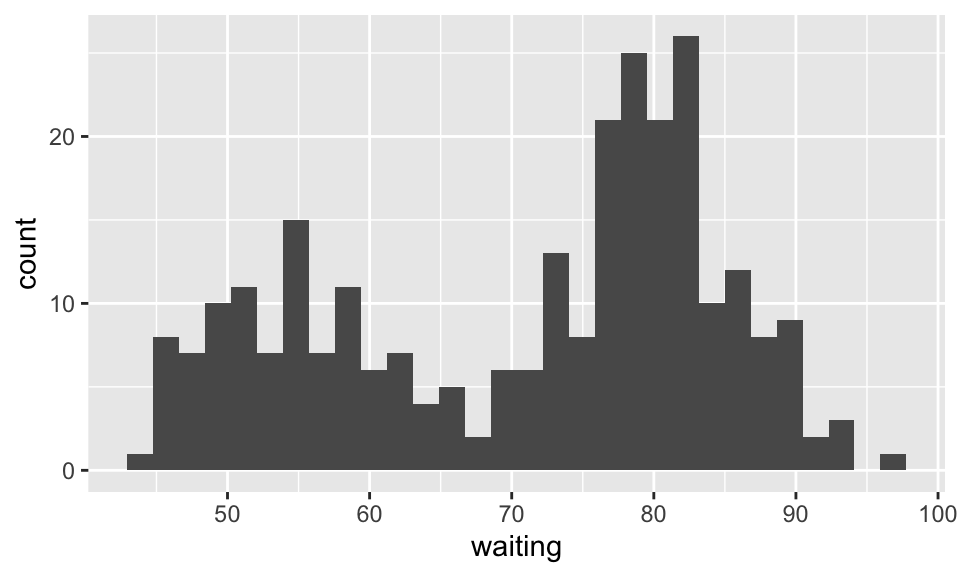

```r
ggplot(data = df, aes(x=waiting)) +
  geom_histogram()
```

## Specify the bins

Specifying the bins for a histogram is good practice. You can either specify the bin widths with the `binwidth` option inside the `geom_histogram()` command, or you can specify the total number of bins with the `bins` option.

#### Using `binwidth` option

In the following graph, each bin has width 4.

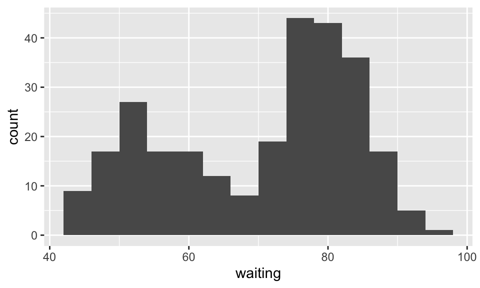

```r
ggplot(data = df, aes(x=waiting)) +
  geom_histogram(binwidth = 4)
```

#### Using the `bins` option

In the following plot we create 20 equal width bins

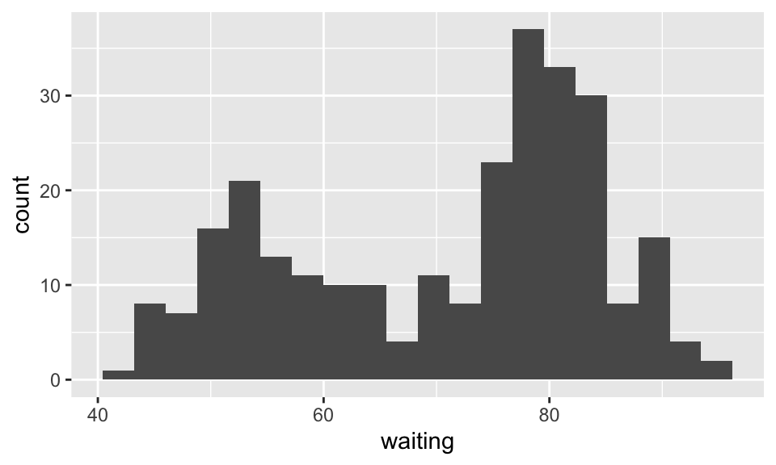

```r
ggplot(data = df, aes(x=waiting)) +
  geom_histogram(bins = 20)
```

## Add color and axis labels

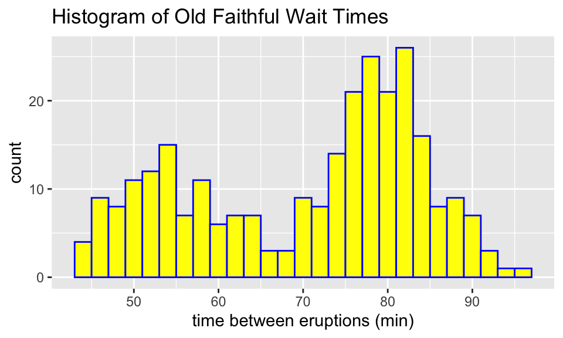

```r
ggplot(data = df,aes(x=waiting)) +
  geom_histogram(binwidth = 2,col="blue",fill="yellow") +
  xlab("time between eruptions (min)") +
  ggtitle("Histogram of Old Faithful Wait Times")
```

The `col` option colors the boundary of each bar, the `fill` option colors the interior of each bar. If we want to change the y-axis label, we use the code `ylab("enter new label here inside quotes")`.

## Change the theme

If you’re not a fan of the gray plot background, you can change the theme. Here are two other options:

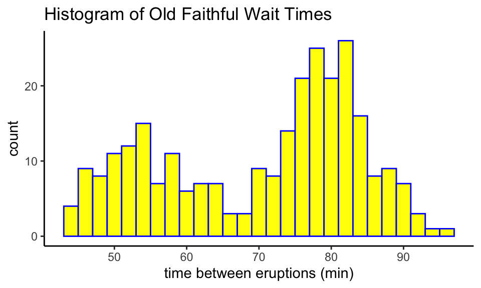

```r
ggplot(data = df,aes(x=waiting)) +
  geom_histogram(binwidth = 2, col="blue", fill="yellow") +
  xlab("time between eruptions (min)") +
  ggtitle("Histogram of Old Faithful Wait Times") +
  theme_classic()
```

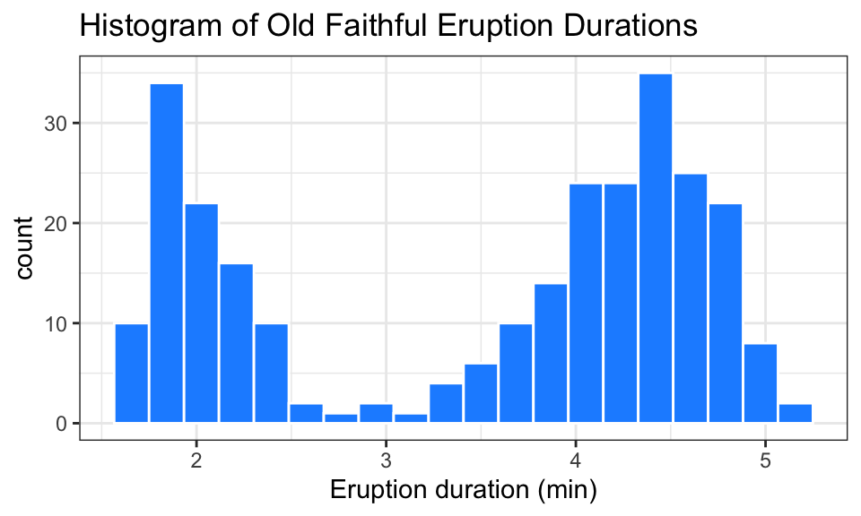

```r
ggplot(data = df,aes(x=eruptions)) +
  geom_histogram(bins = 20, col="white", fill="dodgerblue") +
  xlab("Eruption duration (min)") +
  ggtitle("Histogram of Old Faithful Eruption Durations") +
  theme_bw()
```

Notice in this last plot I changed from binwidths to specifying the number of bins. By the way, I really like the color *dodgerblue* even though I’m not a big Dodgers fan.

## Bonus Round - Density Plot

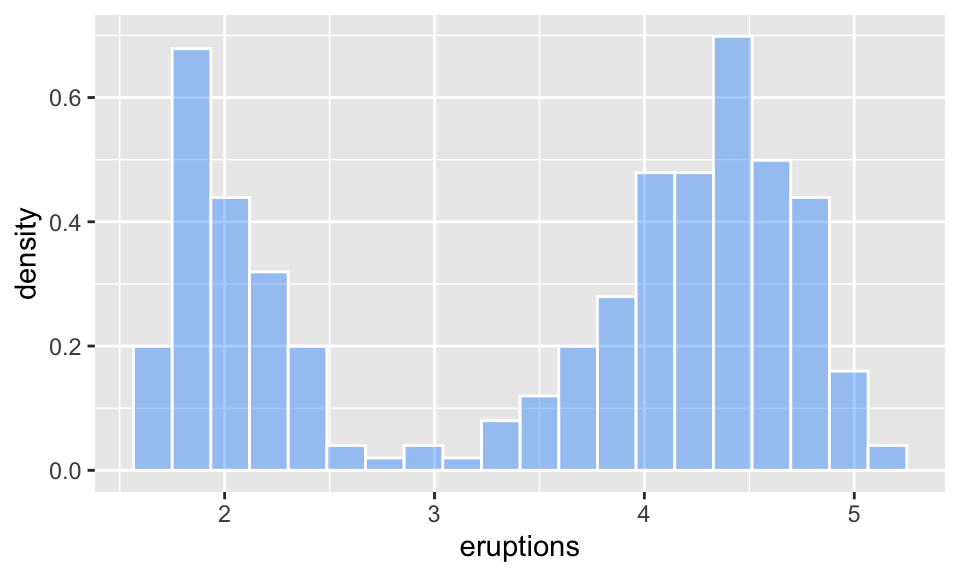

```r
ggplot(df, aes(x=eruptions)) +
  geom_histogram(aes(y = ..density..), bins=20, col="white", fill="dodgerblue",alpha = 0.4)
```

We remark that the `alpha` option above refers to the opacity of the fill color. Values of alpha range from 0 to 1, with lower values corresponding to more transparent colors. So in this plot the dodgerblue color has been made more transparent. If we had set alpha = 1, the color would look as it did in the previous histogram.

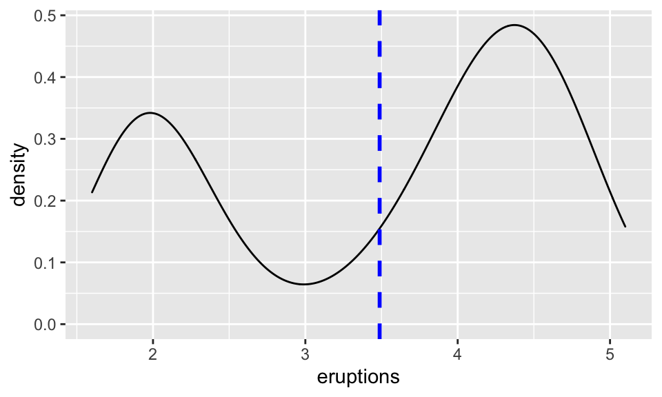

```r
ggplot(df, aes(x=eruptions)) +
  geom_density() +
  geom_vline(aes(xintercept=mean(eruptions)),
            color="blue", linetype="dashed", size=1)
```

The `geom_density()` function gives an idealized density plot rather than a histogram.

The `geom_vline()` option above was thrown in just for fun. It places a vertical line in the graph, for which we’ve specified these options: the color is blue, it is dashed, and it hits the x-axis at the mean value of the eruptions. This distribution is clearly bimodal!!

# Scatter Plots with ggplot

Use the `geom_point()` plot type command, and specify x and y inside `aes()`.

## Basic scatter plot

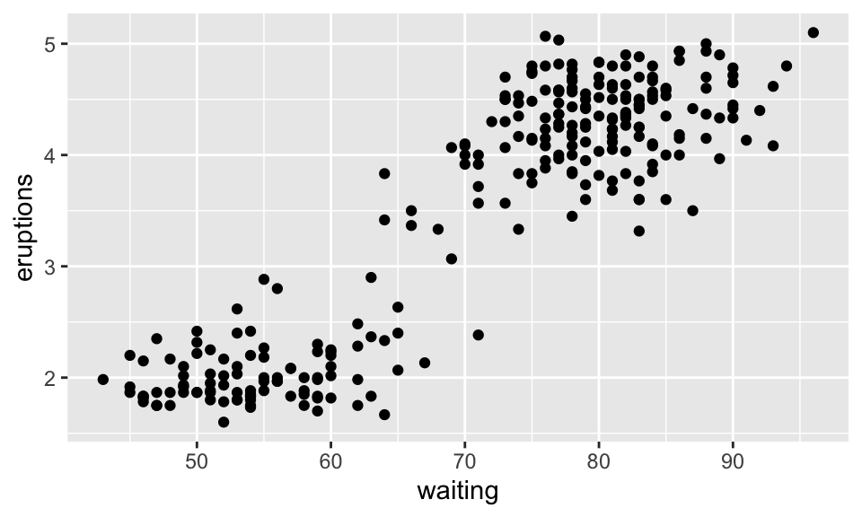

```r
ggplot(data = df,aes(x=waiting,y=eruptions)) +
  geom_point()
```

## Add color and axis labels

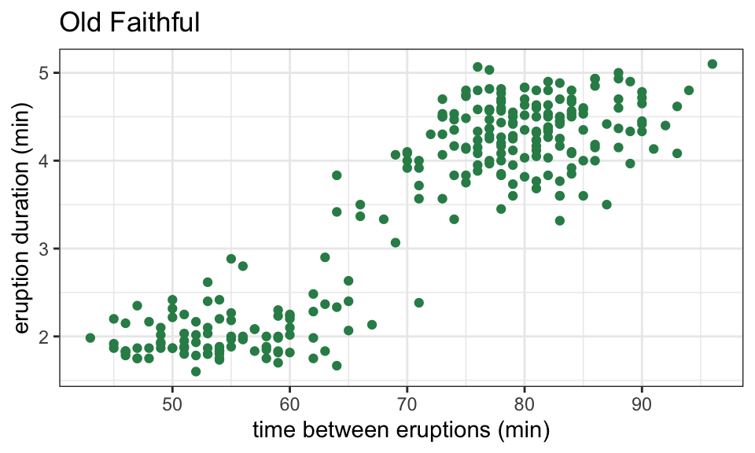

```r
ggplot(data = df,aes(x=waiting,y=eruptions)) +
  geom_point(col="seagreen")+
  xlab("time between eruptions (min)") +
  ylab("eruption duration (min)") +
  ggtitle("Old Faithful") +
  theme_bw()
```

Seagreen! I like it!

R has lots (657) of built-in color names. You can see the names in RStudio if you run `colors()`.

## Add color by category

For the purposes of illustrating the power of ggplot, let’s add a categorical variable to the data frame called `letter` that randomly assigns to each observation the letter *a*, *b*, or *c*.

```r
df$letter = sample(c("a","b","c"),nrow(df),replace=TRUE)
head(df,10)
```

```
##    eruptions waiting letter
## 1      3.600      79      c
## 2      1.800      54      c
## 3      3.333      74      c
## 4      2.283      62      a
## 5      4.533      85      b
## 6      2.883      55      a
## 7      4.700      88      a
## 8      3.600      85      b
## 9      1.950      51      b
## 10     4.350      85      b
```

We can color points in a scatter plot according to a categorical variable by specifying col = this variable *within* the aes() command.

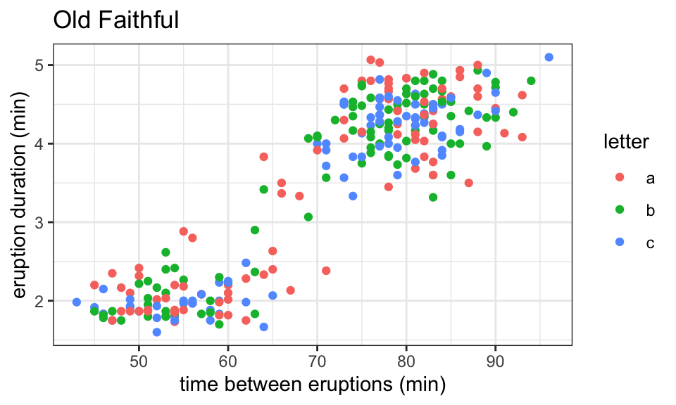

```r
ggplot(data = df,aes(x=waiting,y=eruptions,col=letter)) +
  geom_point()+
  xlab("time between eruptions (min)") +
  ylab("eruption duration (min)") +
  ggtitle("Old Faithful") +
  theme_bw()
```

## Bonus Round - Fit the line

We have two ways to add a line to a plot in ggplot.

#### Using geom_abline()

The first approach is to add the line by specifying the slope and y-intercept using `geom_abline(slope = , intercept = )`.

For instance, the slope and $y$-intercept for the least squares line in the faithful example are 0.07563 and -1.87402, respectively (found by using the code `lm(eruptions~waiting,df)).

Knowing these values we can add a line to a scatter plot by having two layers in our plot: a `geom_point` layer which plots the points, and a `geom_abline` layer which plots the line.

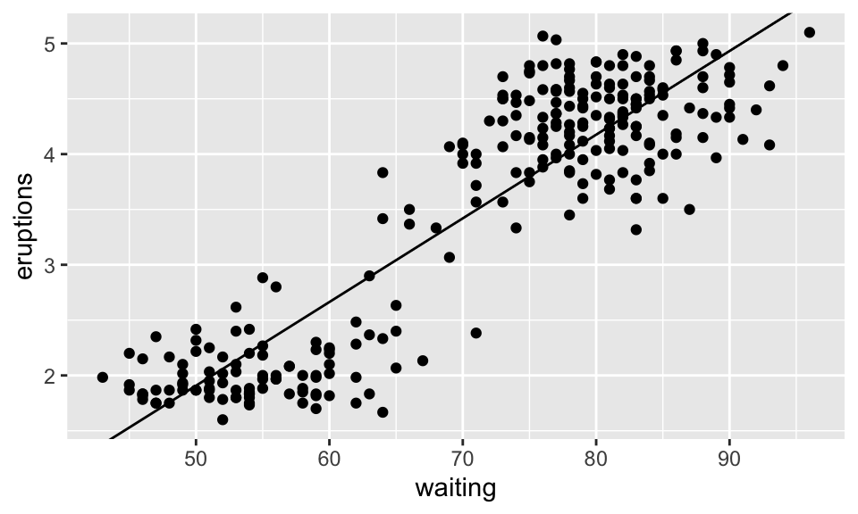

```r
ggplot(data = df,aes(x=waiting,y=eruptions)) +
  geom_point()+
  geom_abline(slope = 0.07563, intercept = -1.87402)
```

We can add color to layers separately, we can change the size of the points and the size of the line, we can change the linetype in the `geom_abline()` layer, and we can add labels to give appropriate details:

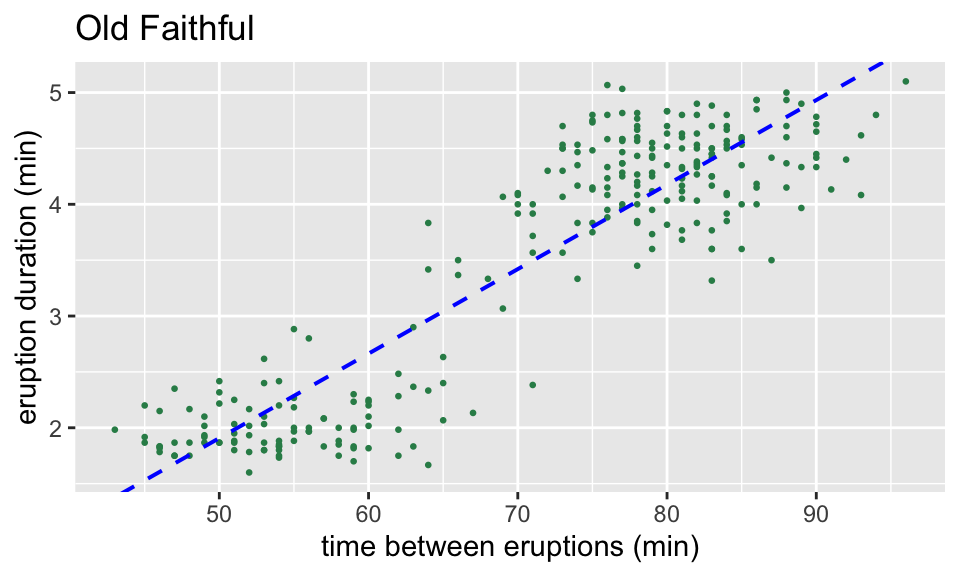

```r
ggplot(data = df,aes(x=waiting,y=eruptions)) +
  geom_point(col="seagreen",size=.5)+
  geom_abline(slope = 0.07563, intercept = -1.87402,col="blue",linetype="dashed",size=.7)+
  xlab("time between eruptions (min)") +
  ylab("eruption duration (min)") +
  ggtitle("Old Faithful")
```

#### Using geom_smooth()

The second approach to fitting a line to data is to use the `geom_smooth()`command. Here’s how to add the least squares regression line to the scatter plot:

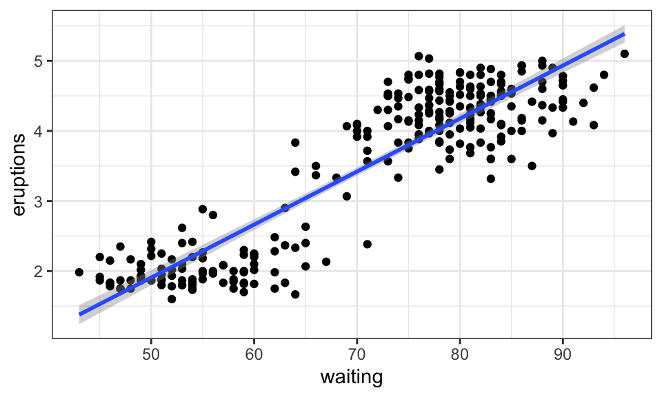

```r
ggplot(data = df,aes(x=waiting, y = eruptions)) +
  geom_point() +
  geom_smooth(method='lm', formula=y~x) +
  theme_bw()
```

The gray bar of varying thickness surrounding the least squares regression line is called a confidence band, something we won’t consider here. To remove it from a plot, add the `se = FALSE` option in your geom_smooth() line. While we’re at it, let’s spruce up the look of it all:

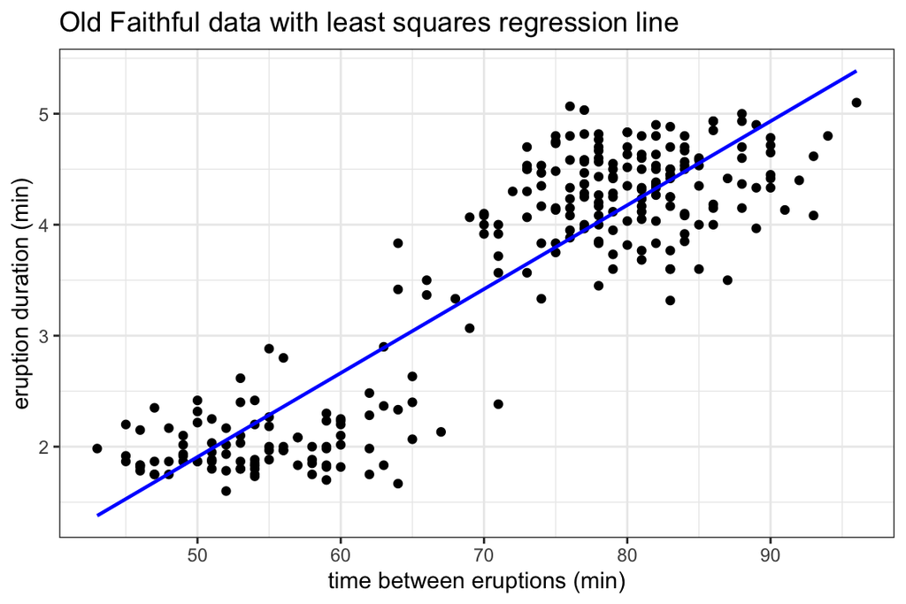

```r
ggplot(data = df,aes(x=waiting, y = eruptions)) +
  geom_point() +
  geom_smooth(method='lm', formula=y~x, col="blue",size=.8,se=FALSE) +
  xlab("time between eruptions (min)") +
  ylab("eruption duration (min)") +
  ggtitle("Old Faithful data with least squares regression line") +
  theme_bw()
```

# Box plots with ggplot

## Basic box plot

Use the `geom_boxplot()` plot type command.

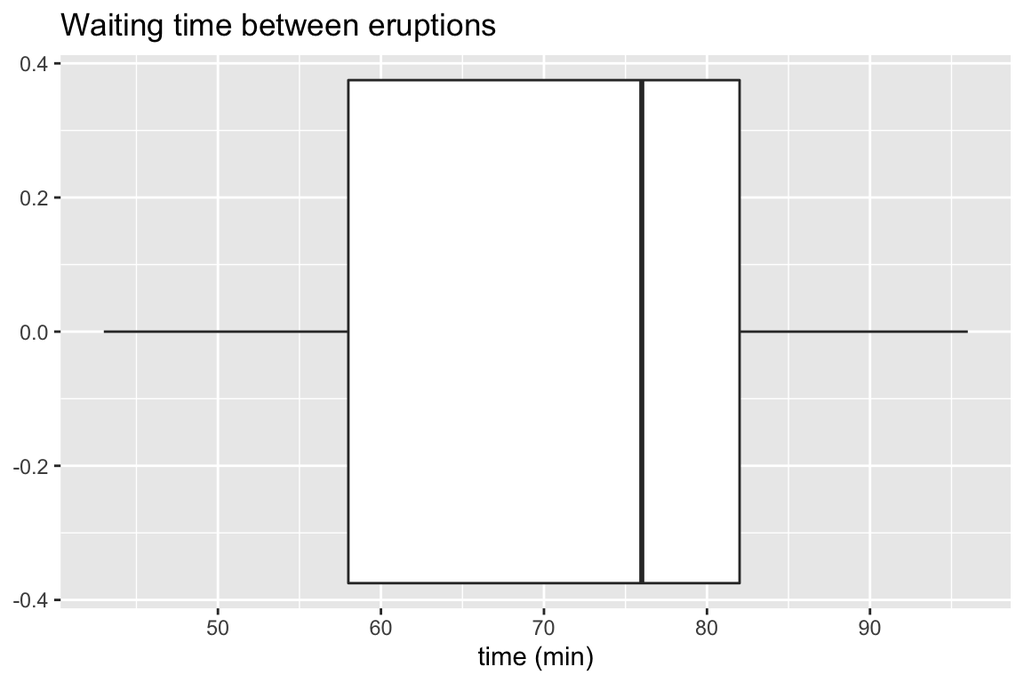

```r
ggplot(data = df,aes(x=waiting)) +
  geom_boxplot() +
  xlab("time (min)") +
  ggtitle("Waiting time between eruptions")
```

This plot is unsatisfying because it gives values on the y-axis, which are meaningless in the context of this box plot. We can hide them:

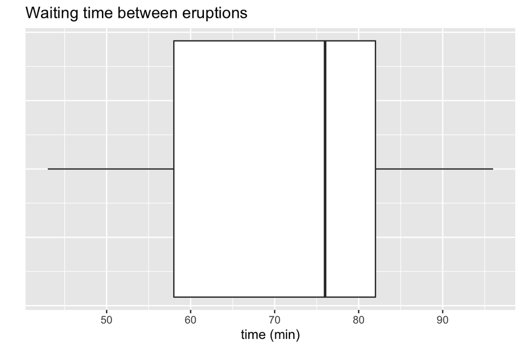

```r
ggplot(data = df,aes(x=waiting)) +
  geom_boxplot() +
  xlab("time (min)") +
  ylab(" ") +
  ggtitle("Waiting time between eruptions")+
  theme(axis.ticks.y = element_blank(),
        axis.text.y = element_blank())
```

This code is cumbersome, but it get’s the job done.

## Side-by-side box plots

The package `ggplot` makes nice side-by-side box plots quite easily.

If $x$ is a numerical variable and $y$ is a categorical variable, we can determine side-by-side box plots for the values of $x$ grouped by the values of $y$.

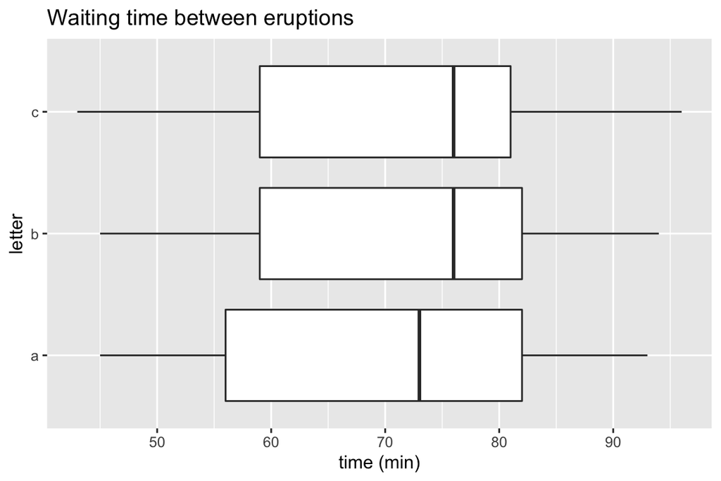

```r
ggplot(data = df,aes(x=waiting,y=letter)) +
  geom_boxplot() +
  xlab("time (min)") +
  ylab("letter") +
  ggtitle("Waiting time between eruptions")
```

Since the letters “a”, “b”, and “c” were assigned at random to the different eruptions, it is not surprising that the box plots for each letter type are roughly the same.

## Coloring box plots

We can fill box plots with color according to a categorical variable using the `fill` option.

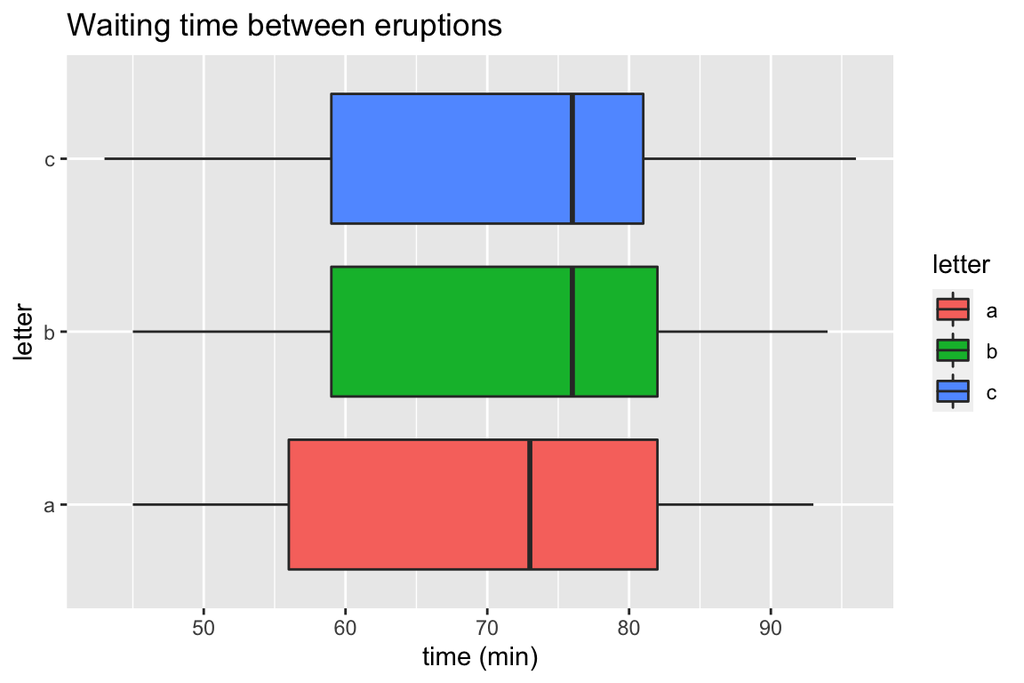

```r
ggplot(data = df,aes(x=waiting,y=letter,fill=letter)) +
  geom_boxplot() +
  xlab("time (min)") +
  ylab("letter") +
  ggtitle("Waiting time between eruptions")
```

## Hiding the legend

We can hide the legend if it is superfluous, as it is above, by adding `show.legend = FALSE` inside the `geom_boxplot()` command.

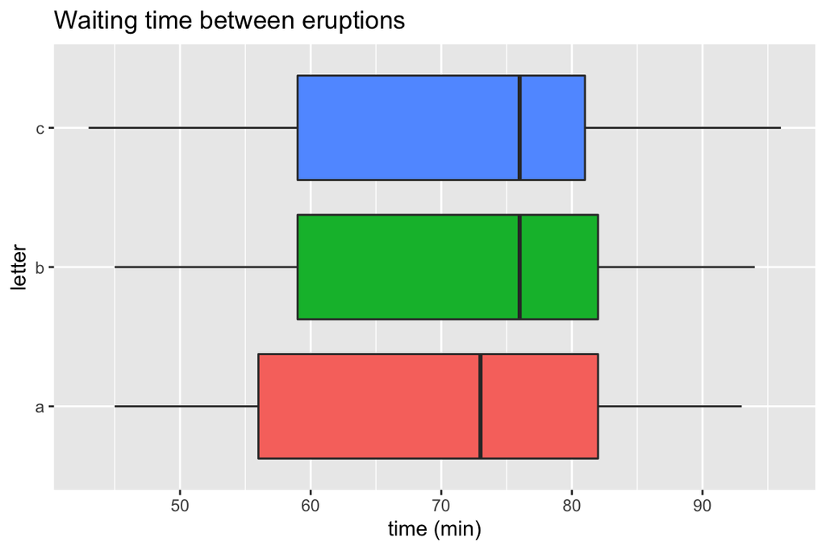

```r
ggplot(data = df,aes(x=waiting,y=letter,fill=letter)) +
  geom_boxplot(show.legend = FALSE) +
  xlab("time (min)") +
  ylab("letter") +
  ggtitle("Waiting time between eruptions")
```

## Customizing colors

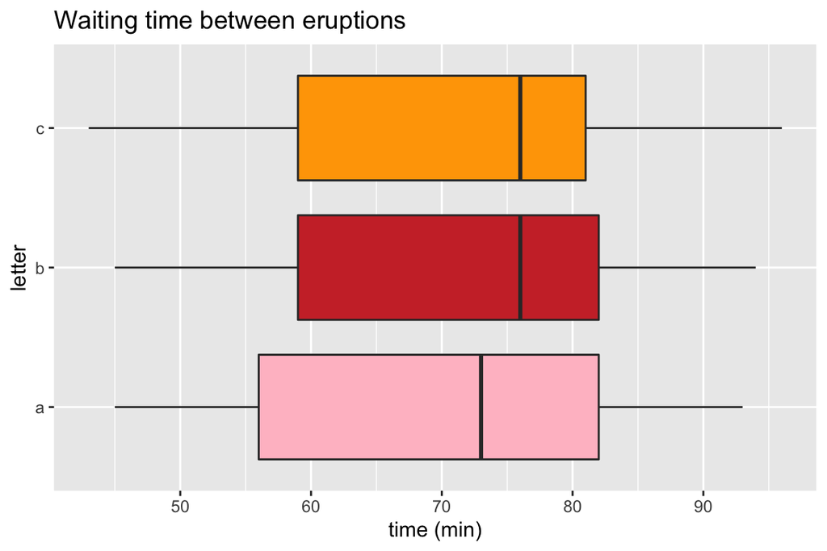

```r
ggplot(data = df,aes(x=waiting,y=letter)) +
  geom_boxplot(fill=c("pink","brown3","orange")) +
  xlab("time (min)") +
  ylab("letter") +
  ggtitle("Waiting time between eruptions")
```

Note: Since the categorical variable `letter` has 3 different values, we specify 3 different colors in the geom_boxplot() command, and these colors are expressed as a vector (inside the `c()` method).

## Bonus Round - Color Opacity

As mentioned in the histogram section, the `alpha` option adjusts the opacity of a color in a plot. The closer alpha is to 0, the more transparent it becomes, and the closer to 1, the more opaque it becomes. In the graph below the three box plots are all filled with the color “orange” but with different alpha values.

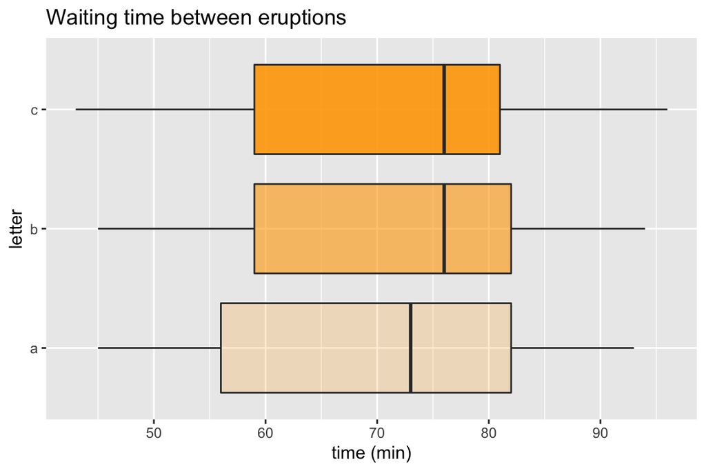

```r
ggplot(data = df,aes(x=waiting,y=letter)) +
  geom_boxplot(fill="orange", alpha=c(.2, .6, .9)) +
  xlab("time (min)") +
  ylab("letter") +
  ggtitle("Waiting time between eruptions")
```

# Bonus plot - bar plot for categorical variable

In Base R we can visualize the frequencies for a categorical variable as follows:

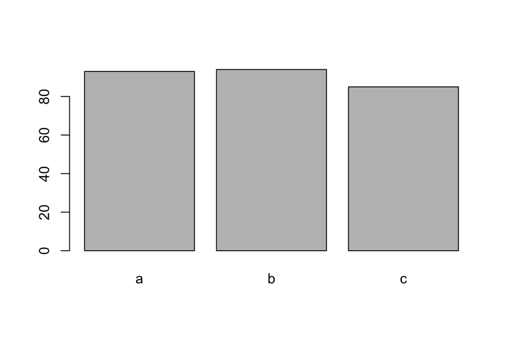

```r
barplot(table(df$letter))
```

We can also create a bar plot with gglplot with the following code:

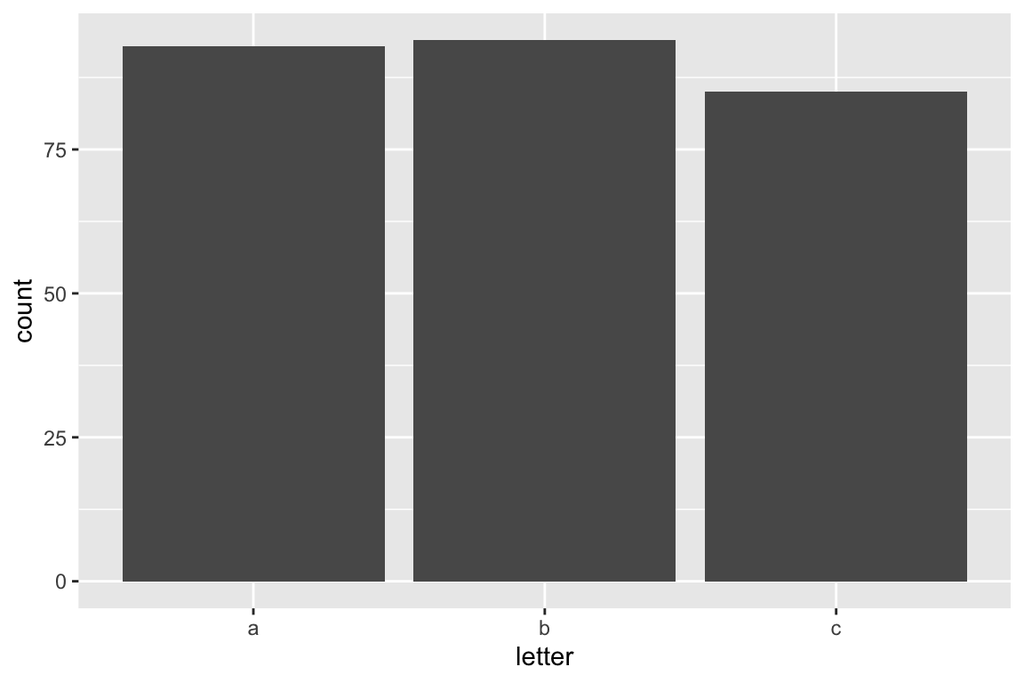

```r
ggplot(data=df,aes(x=letter))+
  geom_bar(stat="count")
```

And we can add color, change bar width, and add labels as usual. We can also speficy the limits of the values on the y-axis to be, say, 0 to 100:

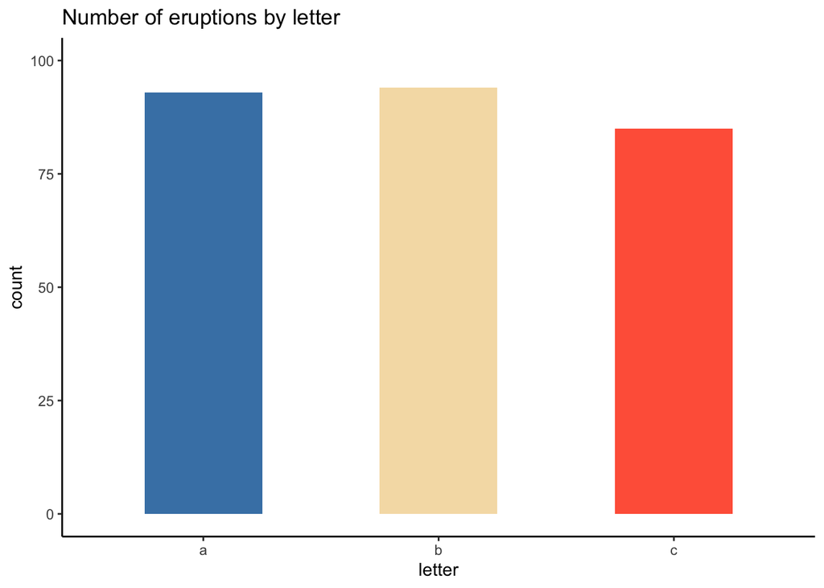

```r
ggplot(data=df,aes(x=letter))+
  geom_bar(stat="count", width=.5, fill=c("steelblue","wheat","tomato"))+
  ylim(0,100)+
  ggtitle("Number of eruptions by letter")+
  theme_classic()
```